# Análise Exploratória de Falhas

Israel

2025-02-12

## 1. Carregamento e Preparação dos Dados

## Visualização das primeiras linhas

```r
head(dados)
```

```
## # A tibble: 6 × 12
##   ID           `DATA DETECCAO` PONTO LOC_ID LOC   POS_ID POS   TYPE_ID TYPE_TEXT
##   <chr>        <chr>           <chr>  <dbl> <chr>  <dbl> <chr>   <dbl> <chr>
## 1 2024-3712154 2010-01-29-02.… RODA… 5.56e3 Tamp…     -2 <NA>       70 "070 - R…
## 2 2024-3722068 2010-01-29-02.… RODA… 5.56e3 Tamp…     -2 <NA>       70 "070 - R…
## 3 2024-3732080 2010-01-29-02.… RODA… 7.06e3 Reve…      5 dire…      70 "070 - R…
## 4 2024-3732079 2010-01-29-02.… RODA… 5.85e3 Port…      5 dire…      70 "070 - R…
## 5 2024-3711076 2010-01-29-02.… RODA… 4.66e3 Alav…     -2 <NA>        5 "005 - B…
## 6 2024-3732094 2010-01-29-04.… RODA… 9.88e7 Regu…      3 esqu…      31 "031 - P…
## # ℹ 3 more variables: VIEW_ID <dbl>, COLUNA <chr>, LINHA <dbl>
```

## Verificação da estrutura dos dados

```r
str(dados)
```

```
## spc_tbl_ [679,073 × 12] (S3: spec_tbl_df/tbl_df/tbl/data.frame)
##  $ ID           : chr [1:679073] "2024-3712154" "2024-3722068" "2024-3732080" "2024-3732079" ...
##  $ DATA DETECCAO: chr [1:679073] "2010-01-29-02.25.25.000000" "2010-01-29-02.38.57.000000" "2010-01-29-02.44.54.000000" "2010-01-29-02.53.28.000000" ...
##  $ PONTO        : chr [1:679073] "RODAGEM" "RODAGEM" "RODAGEM" "RODAGEM" ...
##  $ LOC_ID       : num [1:679073] 5559 5559 7057 5851 4661 ...
##  $ LOC          : chr [1:679073] "Tampa traseira" "Tampa traseira" "Revestimento coluna A" "Porta traseira" ...
##  $ POS_ID       : num [1:679073] -2 -2 5 5 -2 3 3 5 4 3 ...
##  $ POS          : chr [1:679073] NA NA "direita" "direita" ...
##  $ TYPE_ID      : num [1:679073] 70 70 70 70 5 31 70 70 70 70 ...
##  $ TYPE_TEXT    : chr [1:679073] "070 - Ruído" "070 - Ruído" "070 - Ruído" "070 - Ruído" ...
##  $ VIEW_ID      : num [1:679073] NA NA NA NA NA NA NA NA NA NA ...
##  $ COLUNA       : chr [1:679073] NA NA NA NA ...
##  $ LINHA        : num [1:679073] NA NA NA NA NA NA NA NA NA NA ...
##  - attr(*, "spec")=
##   .. cols(
##   ..   ID = col_character(),
##   ..   `DATA DETECCAO` = col_character(),
##   ..   PONTO = col_character(),
##   ..   LOC_ID = col_double(),
##   ..   LOC = col_character(),
##   ..   POS_ID = col_double(),
##   ..   POS = col_character(),
##   ..   TYPE_ID = col_double(),
##   ..   TYPE_TEXT = col_character(),
##   ..   VIEW_ID = col_double(),
##   ..   COLUNA = col_character(),
##   ..   LINHA = col_double()
##   .. )
##  - attr(*, "problems")=<externalptr>
```

## 2. Resumo Estatístico e Descrição dos Dados

## Resumo estatístico

```r
summary(dados)
```

```
##       ID            DATA DETECCAO         PONTO               LOC_ID
##  Length:679073      Length:679073      Length:679073      Min.   :    1001
##  Class :character   Class :character   Class :character   1st Qu.:    5145
##  Mode  :character   Mode  :character   Mode  :character   Median :    5559
##                                                           Mean   : 3520407
##                                                           3rd Qu.:    5851
##                                                           Max.   :99008995
##
##      LOC                POS_ID            POS               TYPE_ID
##  Length:679073      Min.   :     -2   Length:679073      Min.   :       1
##  Class :character   1st Qu.:      1   Class :character   1st Qu.:      39
##  Mode  :character   Median :     10   Mode  :character   Median :      89
##                     Mean   :  49464                      Mean   : 5766978
##                     3rd Qu.:     17                      3rd Qu.:     126
##                     Max.   :9799976                      Max.   :99008934
##
##   TYPE_TEXT            VIEW_ID         COLUNA              LINHA
##  Length:679073      Min.   :661.0   Length:679073      Min.   :1.00
##  Class :character   1st Qu.:673.0   Class :character   1st Qu.:2.00
##  Mode  :character   Median :689.0   Mode  :character   Median :3.00
##                     Mean   :699.3                      Mean   :3.25
##                     3rd Qu.:723.0                      3rd Qu.:4.00
##                     Max.   :778.0                      Max.   :6.00
##                     NA's   :98563                      NA's   :98564
```

### Descrição das variáveis

O conjunto de dados contém as seguintes variáveis: - **ID**: Identificador único da falha. - **DATA DETECCAO**: Data e hora em que a falha foi detectada. - **PONTO**: Local do problema. - **LOC_ID**: Identificação numérica da localização. - **LOC**: Descrição da localização. - **POS_ID**: Identificação da posição do problema. - **POS**: Posição textual (ex: esquerda/direita). - **TYPE_ID**: Código do tipo de falha. - **TYPE_TEXT**: Descrição do tipo de falha. - **VIEW_ID**: Identificação do ponto de vista da inspeção. - **COLUNA**: Identificação textual da coluna. - **LINHA**: Identificação numérica da linha.

## 3. Análise Univariada

### Visualização das distribuições

[figure not shown]

```r
ggplot(dados, aes(x = LOC_ID)) +
geom_histogram(binwidth = 50, fill = "blue", color = "black") +
labs(title = "Distribuição de LOC_ID", x = "LOC_ID", y = "Frequência")
```

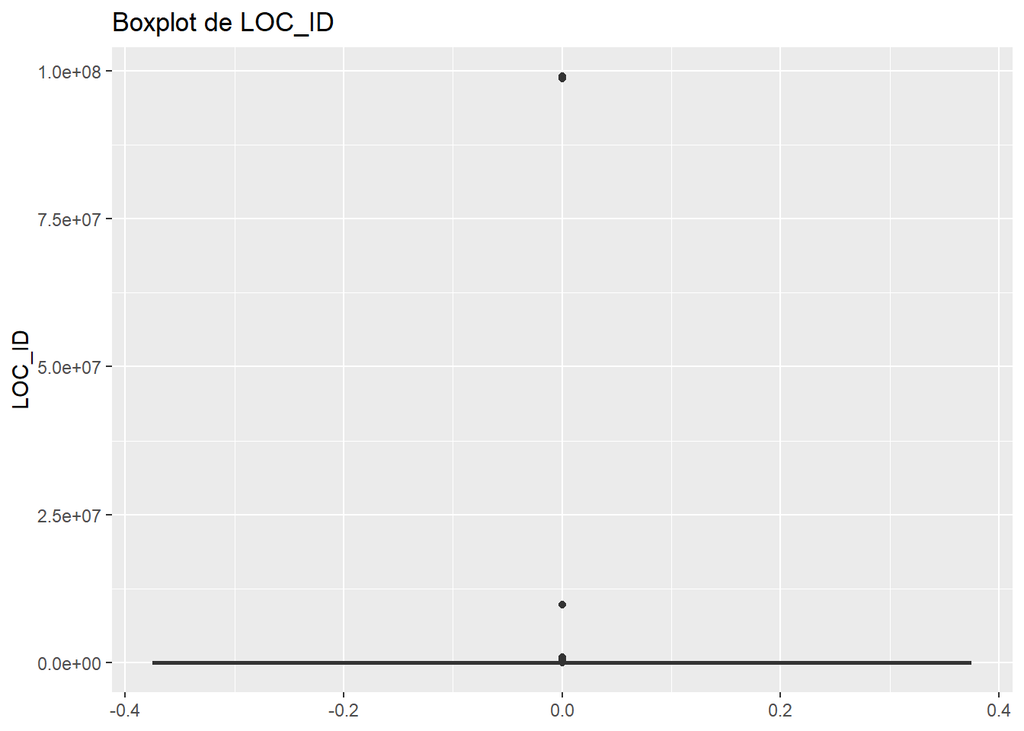

```r
ggplot(dados, aes(y = LOC_ID)) +
geom_boxplot(fill = "orange") +
labs(title = "Boxplot de LOC_ID", y = "LOC_ID")
```

### Identificação de outliers

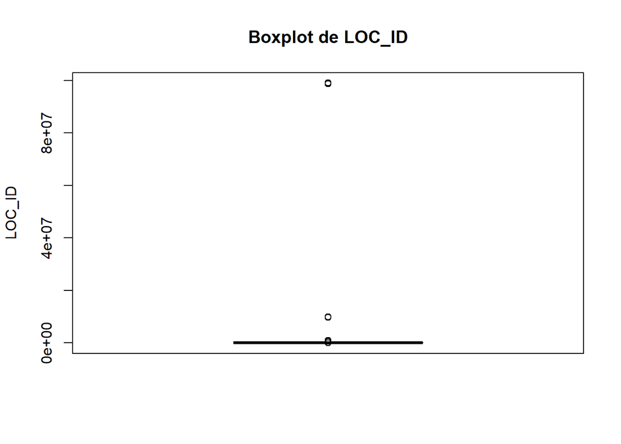

```r
boxplot(dados$LOC_ID, main = "Boxplot de LOC_ID", ylab = "LOC_ID")
```

*A presença de outliers em LOC_ID, que podem indicar falhas atípicas ou erros de registro.*

## 4. Análise Bivariada

### Visualização de relações entre variáveis

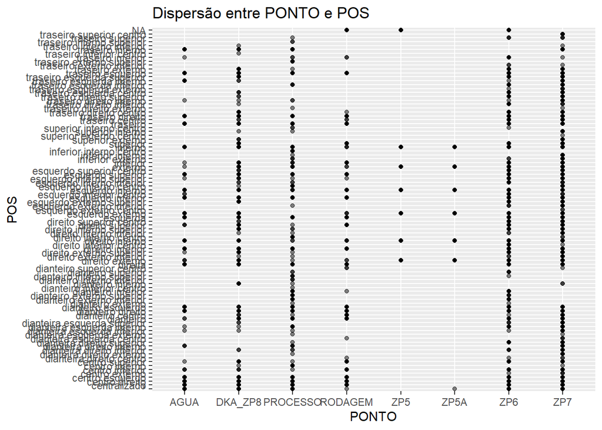

```r
ggplot(dados, aes(x = PONTO, y = POS)) +
geom_point(alpha = 0.5) +
labs(title = "Dispersão entre PONTO e POS", x = "PONTO", y = "POS")
```

### Análise de correlação

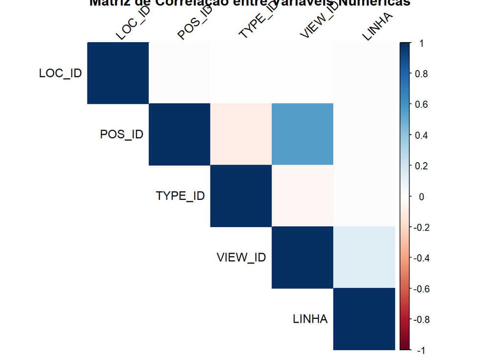

```r
dados_num <- dados %>%
select_if(is.numeric)
cor_matrix <- cor(dados_num, use = "complete.obs")
corrplot(cor_matrix, method = "color", type = "upper",
tl.col = "black", tl.srt = 45,
title = "Matriz de Correlação entre Variáveis Numéricas")
```

## 5. Análise Multivariada

### Análise de Componentes Principais

```r
dados_pca <- dados_num %>%
na.omit() %>%
scale()
```

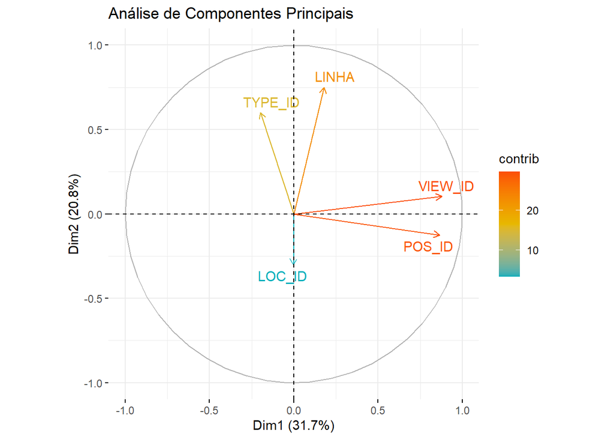

```r
pca_result <- prcomp(dados_pca, center = TRUE, scale. = TRUE)
fviz_pca_var(pca_result,
col.var = "contrib",
gradient.cols = c("#00AFBB", "#E7B800", "#FC4E07"),
repel = TRUE) +
labs(title = "Análise de Componentes Principais")
```

## 6. Conclusão e Discussão

### Discussão sobre limitações e possíveis melhorias

- O dataset possui muitos valores faltantes que podem afetar as análises.
- Algumas variáveis categóricas poderiam ser melhor representadas.
- Seria interessante aprofundar a análise em relação a padrões temporais de falhas.